# Assignment 1 and 2: Prediction Tasks

## Flow of analysis

#### 1. Introduction

1.1. Objective  
1.2. Adopted approach  
1.3. Answers to data science questions

#### 2. Machine learning setup

#### 3. Data exploration of target variables

3.1. Analysis of totshopping.rep (i.e. total spend)  
3.2. Analysis of pov6 (i.e. customer groups)

#### 4. Predicting totshopping.rep

4.1. Baseline random forest model with feature importance  
4.2. Baseline linear model  
4.3. Random forest model with fine-tuned hyper-parameters  
4.4. Gradient boosted tree model with fine-tuned hyper-parameters  
4.5. Baseline deep learning model

#### 5. Predicting pov6

5.1. Baseline random forest model  
5.2. Gradient boosted tree model with fine-tuned hyper-parameters

## 1. Introduction

### 1.1. Objective

The object of this assignment is to the predict *total spend* and *customer groups* from a set of survey data using the most appropriate tools.

After building the appropriate model, a machine learning pipeline will be built to generate these new values based on unseen data.

### 1.2. Adopted approach

The *testdata.csv* will be considered as the holdout set for this task. The reason for the holdout set is to simulate the real-life situation where new data is received, and a prediction would have to be made on the new dataset. Based on the analysis of this assignment, predictions would be made on the holdout set, and outputs on the model performance and final predictions would be available in the model output folder.

The *spenddata.csv* dataset would be used to find the best models for prediction.

Before carrying out the modelling work, a quick exploration of the training dataset would be done to assess the cleanliness of the dataset, and the target variables for predictions.

To understand the dataset better, it would be ideal to understand in more detail the data collection methods, the data-types available in the dataset, the business use-case for each question collected, and the business environment during data collection.

Despite the above limitations, initial modelling will be conducted, with predictions for total spend being carried out using regression methods and customer groups with classification methods where ever possible.

### 1.3. Answers to data science questions

#### The following are the answers for questions 1:

**a. Please explain the choice of metric used**  
The metric used for the regression task is the Root Mean Squared Error (RMSE). As the name suggests, RMSE measures the average squared error of the model, and has the same units as the predicted target. The smaller the RMSE, the better the model. The RMSE is more sensitive to errors made by the model, because of the squared term, as compared to the Mean Absolute Error (MAE). Hence, can be considered as a stricter measure of a model's performance.

**b. What are the assumptions you made when building this model?**  
The main assumption was that discarding the large number of missing columns would not introduce bias into the modelling process. If the reasons for the missing variabe somehow covaries with the missing variable itself, we could introduce some bias if we drop it. This has to be cross-validated with the research design to ensure that dropping largely missing columns would not cause any issues.

**c. What were the approaches you considered? Please explain the reason for the technique / approach used as well as the pros and cons.**  
Given the limited information available on the dataset, an algorithm called Gradient Boosting Machine was used as it has fewer assumptions made about the data as compared to parametric family of models.

The pros of the algorithm is that it has less tendency to overfit, performs better than a single tree/typical random forest and does not take much compute power to train. In addition, it does not require much data pre-processing (such as normalizing, centering, scaling of features) and can handle missing data well. Another advantage of this model is that it is able to generate feature importance, to help explain the model predictions.

On the other hand, the algorithm has a large number of hyper-parameters to tune in order to find the best model. While a base model works well, to develop a highly accurate model it takes time to find the right combination. Also, it may be less interpretable as compared to an generalised linear model, where statistical inference can be carried out to evaluate the predictors.

**d. Please explain under what conditions will the model you choose be not appropriate**  
If the task requires statistical inference, this model may not be as useful. Also, if the data contains a significant amount of outliers, this may not be suitable as the model would tend to over fit.

**e. How confident are you of the model’s robustness and how would you explain the model’s performance?**  
The model is fairly robust given that it does not make many assumptions. It has been shown that esembling methods tend to perform better than a single model.

**f. Why is your model performing well / not well?**  
The model seems to be performing well with a low RMSE of 8.3 and an MAE of 1.8 on the test data.

**g. Was any feature engineering required? If yes, what were they. If no, why?**  
Currently feature engineering is not required to get a good baseline model. However, the performance of the model can be further improved through choosing the right features to build. Good features could be developed through understanding the factors available in the dataset, and some understanding about the tourism domain.

#### The following are the answers for questions 2:

**a. Please explain the choice of metric / evaluation criterion used**  
The metric chosen is the logloss and the accuracy. The logloss is typically used to evaluate the performance of a multinomial classifier. The log loss looks at how close a model's prediction is to the actual target values.

The accuracy of the model is simply the number of correctly predicted class over the total number of predictions made.

**b. What are the assumptions you made when building this model?**  
Given that the GBM was successful in the regression task, it was again used for the classification task. Hence, the assumptions made in the previous tase is the same.

**c. What were the approaches you considered? Please explain the reason for the technique / approach used as well as the pros and cons.**  
The GBM was used as it has shown good performance in the regression task. The pros and cons are similar to that stated above.

As the classes for the training set is imbalanced, over-sampling strategy was employed by the algorithm for the lower frequency classes.

**d. Please explain under what conditions will the model you choose be not appropriate**  
Similar to the above.

**f. Why is your model performing well / not well?**  
One main reason is that the sample size for the lower frequency classes is very low. Hence, errors for those are much higher than the overall rate.

However, while error rates (or recall) may be lower for the lower frequency classes, the model does better on precision for these classes. Hence, in that sense, one can be confident that there would be fewer cases of false positives for the lower frequency classes in this model.

**g. Was any feature engineering required? If yes, what were they. If no, why?**  
Similar to above.

## 2. Machine learning setup

```python
%load_ext autoreload
%autoreload 2
```

The code below sets up the model path to be made available in system path to access modules around the working directory:

```python
import os
import sys

module_path = os.path.abspath(os.path.join('..'))
if module_path not in sys.path:
    sys.path.append(module_path)
```

```python
import missingno as msno
import pandas as pd
import numpy as np
import seaborn as sns
import matplotlib.pyplot as plt
import time

import h2o
from h2o.estimators import H2ORandomForestEstimator
from h2o.estimators.gbm import H2OGradientBoostingEstimator
from h2o.estimators.deeplearning import H2ODeepLearningEstimator
from h2o.estimators.xgboost import H2OXGBoostEstimator
from h2o.grid.grid_search import H2OGridSearch

from sklearn import datasets, linear_model
from sklearn.metrics import mean_squared_error, r2_score

from src.utilities import *

pd.options.display.max_columns = None
```

The code below sets up the local H2o server to use the H2o API for model building:

```python
# If the cluster is running already, shut down and start up a new instance
# h2o.shutdown(prompt=True)

h2o.init(ip="localhost",
         port=54323,
         nthreads = -1,
         max_mem_size = 8)
```

```
Checking whether there is an H2O instance running at http://localhost:54323 ..... not found.
Attempting to start a local H2O server...
; Java HotSpot(TM) 64-Bit Server VM (build 25.231-b11, mixed mode)
  Starting server from C:\Users\aznor\Anaconda3\envs\stb\lib\site-packages\h2o\backend\bin\h2o.jar
  Ice root: C:\Users\aznor\AppData\Local\Temp\tmp8raswvbc
  JVM stdout: C:\Users\aznor\AppData\Local\Temp\tmp8raswvbc\h2o_aznor_started_from_python.out
  JVM stderr: C:\Users\aznor\AppData\Local\Temp\tmp8raswvbc\h2o_aznor_started_from_python.err
  Server is running at http://127.0.0.1:54323
Connecting to H2O server at http://127.0.0.1:54323 ... successful.
```

| H2O cluster uptime: | 02 secs |
| --- | --- |
| H2O cluster timezone: | Asia/Singapore |
| H2O data parsing timezone: | UTC |
| H2O cluster version: | 3.28.1.3 |
| H2O cluster version age: | 3 days |
| H2O cluster name: | H2O_from_python_aznor_hgvaeh |
| H2O cluster total nodes: | 1 |
| H2O cluster free memory: | 7.111 Gb |
| H2O cluster total cores: | 12 |
| H2O cluster allowed cores: | 12 |
| H2O cluster status: | accepting new members, healthy |
| H2O connection url: | http://127.0.0.1:54323 |
| H2O connection proxy: | {'http': None, 'https': None} |
| H2O internal security: | False |
| H2O API Extensions: | Amazon S3, Algos, AutoML, Core V3, TargetEncoder, Core V4 |
| Python version: | 3.7.6 final |

## 3. Data exploration of target variables

### Summary of data descriptions

- Spend data consists of 18,379 total customers surveyed in 2016, consistently over a monthly basis (~1.5k per month).
- Missing data:
  - 14.4% of the dataframe are missing values.
  - Most variables do not have missing data (about 76% (or 227) variables have no missing values).
  - About 15% (or 45 variables) have more than 30% missing data.
    - likely due to research design, e.g. some questions were asked in some months not in others / some questions asked for certain participants but not others.
  - For the remaining 9% (or 27 variables), they have fewer missing data and could be missing because of the following reasons:
    - Data missing correlated to other variables
      - Hence data cleaning steps could take these factors into account

```python
spend = pd.read_csv("../data/0_raw/spendata.csv")
spend = spend.drop(['t.158', "Unnamed: 0"], axis=1)
spend = spend.sort_values(by = "month")
spend
```

|  | month | var8 | var6 | a.1 | a.2 | a.3 | a.4 | var5 | b.5 | b.6 | b.7 | b.8 | b.9 | b.10 | b.11 | b.12 | b.13 | b.14 | b.15 | b.16 | b.17 | b.18 | b.19 | b.20 | b.21 | b.22 | pov6 | b.23 | b.24 | … |
| --- | --- | --- | --- | --- | --- | --- | --- | --- | --- | --- | --- | --- | --- | --- | --- | --- | --- | --- | --- | --- | --- | --- | --- | --- | --- | --- | --- | --- | --- | --- |
| 0 | 1 | 2.0 | NaN | 1 | 5 | 1 | 57 | 34 | 1 | NaN | 1 | 1.0 | 2 | NaN | NaN | 2 | NaN | NaN | 6 | 6 | 6.0 | 6.0 | 7 | 0.0 | 0.0 | 14 | 1 | 0 | 0 | … |
| 1146 | 1 | 1.0 | NaN | 1 | 4 | 1 | 44 | 21 | 1 | NaN | 1 | 1.0 | 2 | NaN | NaN | 2 | NaN | NaN | 29 | 29 | 29.0 | 29.0 | 11 | 0.0 | 0.0 | 45 | 2 | 14 | 13 | … |
| 1145 | 1 | 1.0 | NaN | 1 | 6 | 1 | 44 | 21 | 2 | 2.0 | 3 | NaN | 1 | 200.0 | 2.0 | 2 | NaN | NaN | 0 | 0 | 0.5 | 0.5 | 1 | 0.0 | 0.0 | 102 | 2 | 120 | 0 | … |
| 1144 | 1 | 1.0 | NaN | 1 | 6 | 1 | 44 | 21 | 2 | 1.0 | 3 | NaN | 1 | 121.0 | 1.0 | 2 | NaN | NaN | 1 | 1 | 1.0 | 1.0 | 2 | 0.0 | 0.0 | 97 | 2 | 119 | 0 | … |
| 1143 | 1 | 1.0 | NaN | 1 | 7 | 1 | 25 | 29 | 2 | 1.0 | 1 | 1.0 | 2 | NaN | NaN | 2 | NaN | NaN | 1 | 1 | 1.0 | 1.0 | 2 | 0.0 | 0.0 | 45 | 2 | 14 | 0 | … |
| ... | ... | ... | ... | ... | ... | ... | ... | ... | ... | ... | ... | ... | ... | ... | ... | ... | ... | ... | ... | ... | ... | ... | ... | ... | ... | ... | ... | ... | ... | … |
| 17331 | 12 | 3.0 | NaN | 1 | 10 | 1 | 57 | 34 | 2 | 4.0 | 1 | 1.0 | 2 | NaN | NaN | 2 | NaN | NaN | 3 | 3 | 3.0 | 3.0 | 4 | NaN | NaN | 13 | 1 | 14 | 122 | … |
| 17330 | 12 | 3.0 | NaN | 1 | 9 | 1 | 57 | 34 | 2 | 4.0 | 1 | 1.0 | 2 | NaN | NaN | 2 | NaN | NaN | 3 | 3 | 3.0 | 3.0 | 4 | NaN | NaN | 14 | 1 | 13 | 0 | … |
| 17329 | 12 | 3.0 | NaN | 1 | 7 | 1 | 57 | 34 | 2 | 4.0 | 1 | 1.0 | 2 | NaN | NaN | 2 | NaN | NaN | 3 | 3 | 3.0 | 3.0 | 4 | NaN | NaN | 14 | 1 | 13 | 0 | … |
| 17351 | 12 | 1.0 | NaN | 1 | 5 | 1 | 65 | 27 | 2 | 4.0 | 1 | 1.0 | 1 | 121.0 | 4.0 | 2 | NaN | NaN | 4 | 4 | 4.0 | 4.0 | 5 | NaN | NaN | 13 | 1 | 14 | 15 | … |
| 18378 | 12 | 3.0 | NaN | 1 | 6 | 1 | 10 | 33 | 1 | NaN | 1 | 1.0 | 2 | NaN | NaN | 2 | NaN | NaN | 1 | 1 | 1.0 | 1.0 | 2 | NaN | NaN | 31 | 2 | 0 | 0 | … |

18379 rows × 299 columns

```python
col_not_missing = select_col_missing(spend, "missing equals", 0)
```

```
Checking data sparsity:
227 variables or about 75% of features with 0% missing values
```

```python
col_many_missing = select_col_missing(spend, "missing more than", 0.30)
```

```
Checking data sparsity:
45 variables or about 15% of features with more than 30% missing values
```

```python
selected_col = select_col_missing(spend, "missing less than equals to", 0.30)
```

```
Checking data sparsity:
254 variables or about 84% of features with less than equals to 30% missing values
```

Show missingness of selected columns below, to confirm the selection of columns.  
For reference on the visualisation, use this link https://github.com/ResidentMario/missingno

```
Visualising proportion of missingness for each selected feature:
```

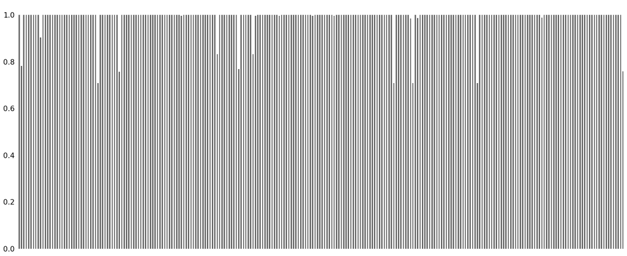

```python
print("Visualising proportion of missingness for each selected feature:")
msno.bar(spend[selected_col])
```

The selected columns' missingness does not seem to have any relationship with months:

```
Visualising missing data for all columns and rows:
```

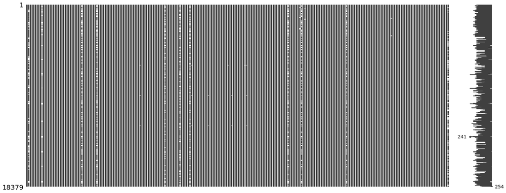

```python
print("Visualising missing data for all columns and rows:")
msno.matrix(spend[selected_col])
```

The missingno correlation heatmap measures nullity correlation: how strongly the presence or absence of one variable affects the presence of another:

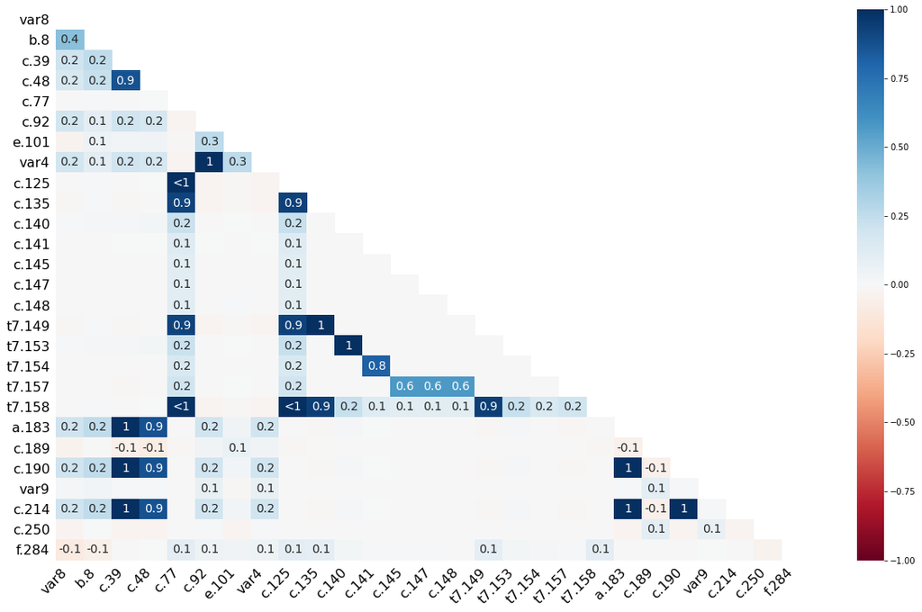

```python
msno.heatmap(spend[selected_col])
```

The above heatmap shows the nullity correlation. The following describes the meaning of the correlation from the missingno module:

"Nullity correlation ranges from -1 (if one variable appears the other definitely does not) to 0 (variables appearing or not appearing have no effect on one another) to 1 (if one variable appears the other definitely also does)."

In conclusion, a large majority of the variables have no effect on one another. However, some of the variables have pairwise correlation, and may need further investigation if these are related. For example, if two variables happen to be missing often, it may be a worthwhile effort to check the research design, and assess if there are some groups of respondents more likely to have missing data. Also, during modelling, the large number of missing values have to be dealt with.

```python
test = pd.read_csv("../data/0_raw/testdata.csv")
test = test.drop(["Unnamed: 0"], axis=1)
test
```

|  | month | var8 | var6 | a.1 | a.2 | a.3 | a.4 | var5 | b.5 | b.6 | b.7 | b.8 | b.9 | b.10 | b.11 | b.12 | b.13 | b.14 | b.15 | b.16 | b.17 | b.18 | b.19 | b.20 | b.21 | b.22 | pov6 | b.23 | b.24 | … |
| --- | --- | --- | --- | --- | --- | --- | --- | --- | --- | --- | --- | --- | --- | --- | --- | --- | --- | --- | --- | --- | --- | --- | --- | --- | --- | --- | --- | --- | --- | --- |
| 0 | 1 | 1.0 | NaN | 1 | 11 | 1 | 47 | 8 | 2 | 1.0 | 1 | 1.0 | 1 | 211.0 | 0.0 | 1 | 211.0 | NaN | 12 | 12 | 12.0 | 12.0 | 10 | 0.0 | 0.0 | 31 | NaN | 14 | 0 | … |
| 1 | 1 | 2.0 | NaN | 1 | 11 | 1 | 65 | 27 | 1 | NaN | 1 | 1.0 | 2 | NaN | NaN | 2 | NaN | NaN | 4 | 4 | 4.0 | 4.0 | 5 | 0.0 | 0.0 | 14 | NaN | 0 | 0 | … |
| 2 | 1 | 2.0 | NaN | 1 | 6 | 1 | 65 | 27 | 2 | 1.0 | 1 | 1.0 | 2 | NaN | NaN | 2 | NaN | NaN | 56 | 56 | 56.0 | 56.0 | 12 | 0.0 | 0.0 | 45 | NaN | 0 | 0 | … |
| 3 | 1 | 1.0 | NaN | 1 | 3 | 1 | 3 | 2 | 1 | NaN | 1 | 1.0 | 1 | 35.0 | 3.0 | 1 | 90.0 | NaN | 5 | 5 | 5.0 | 5.0 | 6 | 0.0 | 0.0 | 14 | NaN | 0 | 0 | … |
| 4 | 1 | 1.0 | NaN | 1 | 5 | 1 | 83 | 3 | 1 | NaN | 1 | 4.0 | 1 | 94.0 | 5.0 | 1 | 200.0 | 4.0 | 4 | 4 | 4.0 | 4.0 | 5 | 0.0 | 0.0 | 14 | NaN | 0 | 0 | … |
| ... | ... | ... | ... | ... | ... | ... | ... | ... | ... | ... | ... | ... | ... | ... | ... | ... | ... | ... | ... | ... | ... | ... | ... | ... | ... | ... | ... | ... | ... | … |
| 4590 | 12 | 1.0 | NaN | 1 | 6 | 1 | 7 | 48 | 1 | NaN | 1 | 1.0 | 2 | NaN | NaN | 2 | NaN | NaN | 6 | 6 | 6.0 | 6.0 | 7 | NaN | NaN | 13 | NaN | 14 | 0 | … |
| 4591 | 12 | 3.0 | NaN | 1 | 9 | 1 | 79 | 22 | 2 | 1.0 | 1 | 1.0 | 2 | NaN | NaN | 2 | NaN | NaN | 0 | 0 | 0.5 | 0.5 | 1 | NaN | NaN | 31 | NaN | 0 | 0 | … |
| 4592 | 12 | 3.0 | NaN | 1 | 9 | 1 | 79 | 22 | 2 | 3.0 | 1 | 1.0 | 2 | NaN | NaN | 2 | NaN | NaN | 3 | 3 | 3.0 | 3.0 | 4 | NaN | NaN | 14 | NaN | 31 | 0 | … |
| 4593 | 12 | NaN | NaN | 1 | 5 | 1 | 133 | 25 | 1 | NaN | 1 | 1.0 | 2 | NaN | NaN | 2 | NaN | NaN | 4 | 4 | 4.0 | 4.0 | 5 | NaN | NaN | 9 | NaN | 13 | 14 | … |
| 4594 | 12 | 3.0 | NaN | 1 | 4 | 1 | 79 | 22 | 2 | 2.0 | 1 | 1.0 | 2 | NaN | NaN | 2 | NaN | NaN | 3 | 3 | 3.0 | 3.0 | 4 | NaN | NaN | 15 | NaN | 14 | 0 | … |

4595 rows × 299 columns

### 3.1. Analysis of totshopping.rep (i.e. total spend)

Both figures below suggests that totshopping.rep appears to have a log-normal distribution, which is something to note when carrying out modelling.

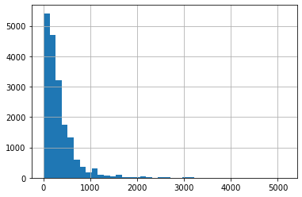

```python
spend["totshopping.rep"].hist(bins = 40)
```

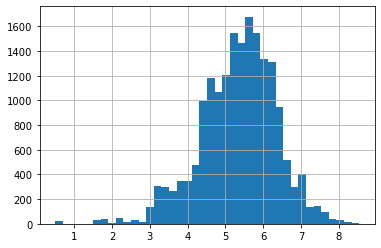

```python
np.log(spend["totshopping.rep"]).hist(bins = 40)
```

### 3.2. Analysis of pov6 (i.e. customer groups)

A large majority of customer groups are in group 1 and 2. This would have to be taken into account during the modelling process.

```
Proportion of responses per customer group:
1    77.245770
2    17.661461
3     1.822732
4     0.995702
5     0.723652
6     1.550683
Name: pov6, dtype: float64
```

```
[Text(0, 0.5, 'Number of responses'), Text(0.5, 0, 'Customer group')]
```

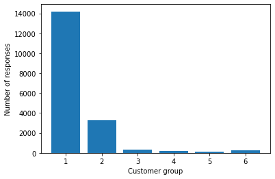

```python
print("Proportion of responses per customer group:")
print(spend["pov6"].value_counts(normalize = True, dropna = False).sort_index() * 100)

fig = plt.figure()
ax = fig.add_subplot(111)

ax.bar(spend["pov6"].value_counts(dropna = False).sort_index().index, spend["pov6"].value_counts().sort_index().tolist())
ax.set(ylabel='Number of responses', xlabel='Customer group')
```

## 4. Predicting totshopping.rep

## 4.1. Baseline random forest model with feature importance

- This model drops columns with large number of nulls from the training set, and fits a default random forest. Given the large number of missing values in the dataset, using the distributed random forest implimented by H2o.ai seems appropriate as missing values in the dataset, are assumed to be missing for a reason, rather than missing at random.
- RMSE achieved for this model is *15.17* on the validation set.
- The model suggets that *var2* has a very high importance to the values of total spend amount.
- Reference to algorithm: http://docs.h2o.ai/h2o/latest-stable/h2o-docs/data-science/drf.html

```python
spend_clean = spend[selected_col]
```

```python
spend
```

|  | month | var8 | var6 | a.1 | a.2 | a.3 | a.4 | var5 | b.5 | b.6 | b.7 | b.8 | b.9 | b.10 | b.11 | b.12 | b.13 | b.14 | b.15 | b.16 | b.17 | b.18 | b.19 | b.20 | b.21 | b.22 | pov6 | b.23 | b.24 | … |
| --- | --- | --- | --- | --- | --- | --- | --- | --- | --- | --- | --- | --- | --- | --- | --- | --- | --- | --- | --- | --- | --- | --- | --- | --- | --- | --- | --- | --- | --- | --- |
| 0 | 1 | 2.0 | NaN | 1 | 5 | 1 | 57 | 34 | 1 | NaN | 1 | 1.0 | 2 | NaN | NaN | 2 | NaN | NaN | 6 | 6 | 6.0 | 6.0 | 7 | 0.0 | 0.0 | 14 | 1 | 0 | 0 | … |
| 1146 | 1 | 1.0 | NaN | 1 | 4 | 1 | 44 | 21 | 1 | NaN | 1 | 1.0 | 2 | NaN | NaN | 2 | NaN | NaN | 29 | 29 | 29.0 | 29.0 | 11 | 0.0 | 0.0 | 45 | 2 | 14 | 13 | … |
| 1145 | 1 | 1.0 | NaN | 1 | 6 | 1 | 44 | 21 | 2 | 2.0 | 3 | NaN | 1 | 200.0 | 2.0 | 2 | NaN | NaN | 0 | 0 | 0.5 | 0.5 | 1 | 0.0 | 0.0 | 102 | 2 | 120 | 0 | … |
| 1144 | 1 | 1.0 | NaN | 1 | 6 | 1 | 44 | 21 | 2 | 1.0 | 3 | NaN | 1 | 121.0 | 1.0 | 2 | NaN | NaN | 1 | 1 | 1.0 | 1.0 | 2 | 0.0 | 0.0 | 97 | 2 | 119 | 0 | … |
| 1143 | 1 | 1.0 | NaN | 1 | 7 | 1 | 25 | 29 | 2 | 1.0 | 1 | 1.0 | 2 | NaN | NaN | 2 | NaN | NaN | 1 | 1 | 1.0 | 1.0 | 2 | 0.0 | 0.0 | 45 | 2 | 14 | 0 | … |
| ... | ... | ... | ... | ... | ... | ... | ... | ... | ... | ... | ... | ... | ... | ... | ... | ... | ... | ... | ... | ... | ... | ... | ... | ... | ... | ... | ... | ... | ... | … |
| 17331 | 12 | 3.0 | NaN | 1 | 10 | 1 | 57 | 34 | 2 | 4.0 | 1 | 1.0 | 2 | NaN | NaN | 2 | NaN | NaN | 3 | 3 | 3.0 | 3.0 | 4 | NaN | NaN | 13 | 1 | 14 | 122 | … |
| 17330 | 12 | 3.0 | NaN | 1 | 9 | 1 | 57 | 34 | 2 | 4.0 | 1 | 1.0 | 2 | NaN | NaN | 2 | NaN | NaN | 3 | 3 | 3.0 | 3.0 | 4 | NaN | NaN | 14 | 1 | 13 | 0 | … |
| 17329 | 12 | 3.0 | NaN | 1 | 7 | 1 | 57 | 34 | 2 | 4.0 | 1 | 1.0 | 2 | NaN | NaN | 2 | NaN | NaN | 3 | 3 | 3.0 | 3.0 | 4 | NaN | NaN | 14 | 1 | 13 | 0 | … |
| 17351 | 12 | 1.0 | NaN | 1 | 5 | 1 | 65 | 27 | 2 | 4.0 | 1 | 1.0 | 1 | 121.0 | 4.0 | 2 | NaN | NaN | 4 | 4 | 4.0 | 4.0 | 5 | NaN | NaN | 13 | 1 | 14 | 15 | … |
| 18378 | 12 | 3.0 | NaN | 1 | 6 | 1 | 10 | 33 | 1 | NaN | 1 | 1.0 | 2 | NaN | NaN | 2 | NaN | NaN | 1 | 1 | 1.0 | 1.0 | 2 | NaN | NaN | 31 | 2 | 0 | 0 | … |

18379 rows × 299 columns

```python
# set the predictor names and the response column name
predictors = spend_clean.columns[~(spend_clean.columns == "totshopping.rep")].tolist()
response = "totshopping.rep"
```

```python
hf = h2o.H2OFrame(spend_clean)
```

```
Parse progress: |█████████████████████████████████████████████████████████| 100%
```

```python
splits = hf.split_frame(ratios=[0.7, 0.15], seed=0)

train_tune = splits[0]
valid_tune = splits[1]
test_tune = splits[2]

print(train_tune.nrow)
print(valid_tune.nrow)
print(test_tune.nrow)
```

```
12928
2743
2708
```

```python
# train a RF model
model_rf = H2ORandomForestEstimator(seed = 0, stopping_metric = "RMSE")
model_rf.train(x = predictors,
               y = response,
               training_frame = train_tune,
               validation_frame = valid_tune)

# retrieve the model performance
model_rf_performance = model_rf.model_performance(test_tune)
model_rf_performance
```

```
drf Model Build progress: |███████████████████████████████████████████████| 100%

ModelMetricsRegression: drf
** Reported on test data. **

MSE: 427.5861630570796
RMSE: 20.67815666487416
MAE: 5.300947246408004
RMSLE: 0.08087972116150745
Mean Residual Deviance: 427.5861630570796
```

The variable importance plot indicates that there are some variables with significant impact on the total spend amount.

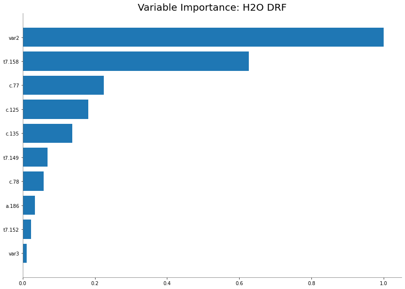

```python
model_rf.varimp_plot()
```

## 4.2. Baseline linear model

We find that a simple linear model validates the findings of the baseline random forest model above.

- R-squared (or coefficient of determination) is on the high range (0.97). This means that approximately 97% of the of the observed variation in the total spending can be explained by the model.
- The coef of var2 also suggests that for every unit increase in var2, a corresponding increase of 1.02 units of totshopping.rep is expected.

```
Coefficients:
 [[1.01894676]]
Mean squared error: 3591.77
Coefficient of determination: 0.97
```

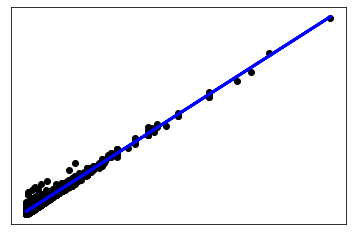

```python
# Split the data into training/testing sets
train_lm, test_lm = split_train_test(spend_clean, 0.2)

X_train_lm = np.array(train_lm[["var2"]]).reshape(-1, 1)
y_train_lm = np.array(train_lm["totshopping.rep"]).reshape(-1, 1)

X_test_lm = np.array(test_lm[["var2"]]).reshape(-1, 1)
y_test_lm = np.array(test_lm["totshopping.rep"]).reshape(-1, 1)


# Create linear regression object
model_lm = linear_model.LinearRegression()

# Train the model using the training sets
model_lm.fit(X_train_lm, y_train_lm)

# Make predictions using the testing set
y_pred_lm = model_lm.predict(X_test_lm)

# The coefficients
print('Coefficients: \n', model_lm.coef_)
# The mean squared error
print('Mean squared error: %.2f'
      % mean_squared_error(y_test_lm, y_pred_lm))
# The coefficient of determination: 1 is perfect prediction
print('Coefficient of determination: %.2f'
      % r2_score(y_test_lm, y_pred_lm))

# Plot outputs
plt.scatter(X_test_lm, y_test_lm,  color='black')
plt.plot(X_test_lm, y_pred_lm, color='blue', linewidth=3)

plt.xticks(())
plt.yticks(())

plt.show()
```

## 4.3. Random forest model with fine-tuned hyper-parameters

- The following trains the random foreset models with combinations of hyper-parameter values to find the best model.

```python
rf_params1 = {'ntrees': [50, 500],
              'max_depth': [100, 500],
              'min_rows': [5, 50],
              'min_split_improvement': [1e-10, 1e-3]}
```

```python
rf_grid1 = H2OGridSearch(model=H2ORandomForestEstimator,
                         grid_id='rf_grid1',
                         hyper_params=rf_params1)


rf_grid1.train(x = predictors,
               y = response,
               training_frame=train_tune,
               validation_frame=valid_tune,
               seed = 0)
```

```
drf Grid Build progress: |████████████████████████████████████████████████| 100%
```

```python
rf_grid1_performance = rf_grid1.get_grid(sort_by='RMSE', decreasing=False)
```

```python
print(rf_grid1_performance)
```

```
     max_depth min_rows min_split_improvement ntrees          model_ids  \
0          100      5.0                 0.001    500  rf_grid1_model_13
1          500      5.0                 0.001    500  rf_grid1_model_14
2          500      5.0               1.0E-10    500  rf_grid1_model_10
3          100      5.0               1.0E-10    500   rf_grid1_model_9
4          100      5.0                 0.001     50   rf_grid1_model_5
5          500      5.0                 0.001     50   rf_grid1_model_6
6          100      5.0               1.0E-10     50   rf_grid1_model_1
7          500      5.0               1.0E-10     50   rf_grid1_model_2
8          100     50.0               1.0E-10    500  rf_grid1_model_11
9          500     50.0               1.0E-10    500  rf_grid1_model_12
10         100     50.0                 0.001    500  rf_grid1_model_15
11         500     50.0                 0.001    500  rf_grid1_model_16
12         100     50.0               1.0E-10     50   rf_grid1_model_3
13         500     50.0               1.0E-10     50   rf_grid1_model_4
```

[output cut: 20 more lines]

```python
rf_grid1_performance.models[0].model_performance(test_tune)
```

```
ModelMetricsRegression: drf
** Reported on test data. **

MSE: 712.4077468814376
RMSE: 26.69096751489982
MAE: 6.233610542758705
RMSLE: 0.10164918451332362
Mean Residual Deviance: 712.4077468814376
```

```python
# RF hyperparameters
rf_params2 = {'ntrees': list(range(500, 800, 200)),
              'max_depth': list(range(10, 50, 10)),
              'min_rows': list(range(1, 5, 2))}

# Search criteria
search_criteria = {'strategy': 'RandomDiscrete', 'max_runtime_secs': 500}
```

```python
rf_grid2 = H2OGridSearch(model=H2ORandomForestEstimator,
                         grid_id='rf_grid2',
                         hyper_params=rf_params2,
                         search_criteria=search_criteria)


rf_grid2.train(x = predictors,
               y = response,
               training_frame=train_tune,
               validation_frame=valid_tune,
               seed = 0)
```

```
drf Grid Build progress: |████████████████████████████████████████████████| 100%
```

```python
rf_grid2_performance = rf_grid2.get_grid(sort_by='RMSE', decreasing=False)
```

```python
rf_grid2_performance.models[0].model_performance(test_tune)
```

```
ModelMetricsRegression: drf
** Reported on test data. **

MSE: 426.762479879792
RMSE: 20.658230318199863
MAE: 4.88452602184883
RMSLE: 0.09069513633673422
Mean Residual Deviance: 426.762479879792
```

## 4.4. Gradient boosted tree model

- The following trains the gradient boosted tree with combinations of hyper-parameter values to find the best model.

```python
# train a GBM model
model_gbm = H2OGradientBoostingEstimator(seed = 0, stopping_metric = "RMSE")
model_gbm.train(x = predictors,
               y = response,
               training_frame = train_tune,
               validation_frame = valid_tune)

# retrieve the model performance
model_gbm_performance = model_gbm.model_performance(test_tune)
model_gbm_performance
```

```
gbm Model Build progress: |███████████████████████████████████████████████| 100%

ModelMetricsRegression: gbm
** Reported on test data. **

MSE: 85.30630306856231
RMSE: 9.236141135158249
MAE: 4.070481687411292
RMSLE: 0.06605124508279617
Mean Residual Deviance: 85.30630306856231
```

```python
print("Model's RMSE on the validation set for totshopping prediction is: {}".format(model_gbm.rmse(valid = True)))
```

```
Model's RMSE on the validation set for totshopping prediction is: 12.49742998473821
```

```python
# GBM hyperparameters
gbm_params1 = {'learn_rate': [0.01, 0.1],
                'max_depth': [3, 5, 9],
                'sample_rate': [0.8, 1.0],
                'col_sample_rate': [0.2, 0.5, 1.0]}
```

```python
gbm_grid1 = H2OGridSearch(model=H2OGradientBoostingEstimator,
                          grid_id='gbm_grid1',
                          hyper_params=gbm_params1)

gbm_grid1.train(x=predictors,
                y=response,
                training_frame=train_tune,
                validation_frame=valid_tune,
                ntrees=100,
                seed=1)
```

```
gbm Grid Build progress: |████████████████████████████████████████████████| 100%
```

```python
gbm_grid_performance1 = gbm_grid1.get_grid(sort_by='RMSE', decreasing=False)
```

```python
print(gbm_grid_performance1)
```

```
     col_sample_rate learn_rate max_depth sample_rate           model_ids  \
0                1.0        0.1         9         0.8  gbm_grid1_model_18
1                1.0        0.1         5         0.8  gbm_grid1_model_12
2                0.5        0.1         9         0.8  gbm_grid1_model_17
3                0.5        0.1         9         1.0  gbm_grid1_model_35
4                0.5        0.1         5         0.8  gbm_grid1_model_11
5                1.0        0.1         3         0.8   gbm_grid1_model_6
6                1.0        0.1         9         1.0  gbm_grid1_model_36
7                0.5        0.1         5         1.0  gbm_grid1_model_29
8                1.0        0.1         5         1.0  gbm_grid1_model_30
9                1.0        0.1         3         1.0  gbm_grid1_model_24
10               0.5        0.1         3         0.8   gbm_grid1_model_5
11               0.5        0.1         3         1.0  gbm_grid1_model_23
12               0.2        0.1         5         1.0  gbm_grid1_model_28
13               0.2        0.1         5         0.8  gbm_grid1_model_10
```

[output cut: 60 more lines]

```python
gbm_grid_performance1.models[0].model_performance(test_tune)
```

```
ModelMetricsRegression: gbm
** Reported on test data. **

MSE: 70.33638547873231
RMSE: 8.38667904946483
MAE: 1.7724730203185997
RMSLE: 0.013477625988268693
Mean Residual Deviance: 70.33638547873231
```

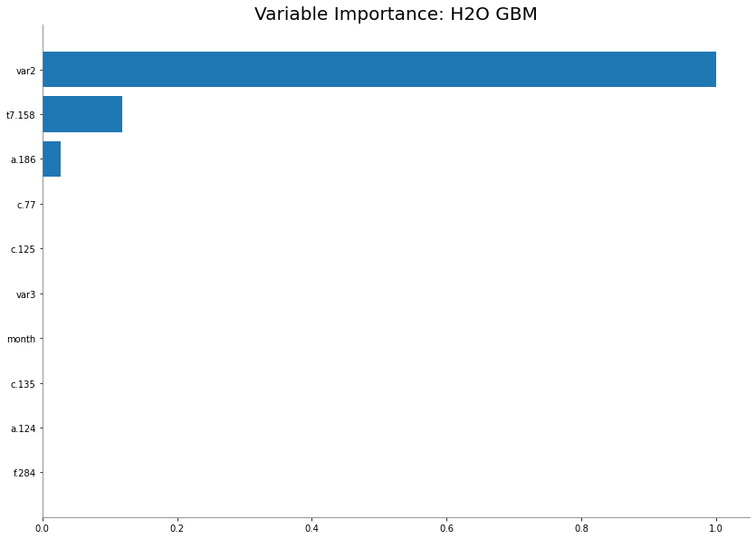

```python
gbm_grid_performance1.models[0].varimp_plot()
```

## 4.5. Deep learning model with fine-tuned hyper-parameters

- The following trains a deep learning model with combinations of hyper-parameter values to find the best model.

```python
activation_opt = ["RectifierWithDropout",
                  "TanhWithDropout"]
#L1 & L2 regularization
l1_opt = [0, 0.00001,
          0.0001,
          0.001,
          0.01,
          0.1]

l2_opt = [0, 0.00001,
          0.0001,
          0.001,
          0.01,
          0.1]



# Create the Hyperparameters
dl_params = {
             'activation': activation_opt,
             "input_dropout_ratio" : [0,0.05, 0.1],  # input layer dropout ratio to improve generalization. Suggested values are 0.1 or 0.2.
             'l1': l1_opt,
             'l2': l2_opt,
             'hidden_dropout_ratios':[[0.1,0.2,0.3], # hidden layer dropout ratio to improve generalization: one value per hidden layer.
                                      [0.1,0.5,0.5],
                                      [0.5,0.5,0.5]]
             }



search_criteria = {
                   'strategy': 'RandomDiscrete',
                   'max_runtime_secs': 1000,
                   'seed':1
                   }



# Prepare the grid object
dl_grid = H2OGridSearch(model=H2ODeepLearningEstimator(
                        epochs = 1000,
                        adaptive_rate = True,
                        stopping_metric="AUTO",
                        stopping_tolerance=1e-2,
                        stopping_rounds=3,
                        hidden=[128,128,128],
                        balance_classes= False,
                        standardize = True,
                        loss = "quantile"
                        ),
                        grid_id='dl_grid',
                        hyper_params=dl_params,
                        search_criteria=search_criteria)



# Train the Model
start = time.time()
dl_grid.train(x=predictors,y=response,
                training_frame=train_tune,
                validation_frame=valid_tune,
                stopping_rounds=2,
                stopping_tolerance=0.0005,
                seed=0
                )

end = time.time()
(end - start)/60
```

```
deeplearning Grid Build progress: |███████████████████████████████████████| 100%
```

```
16.700979721546172
```

```python
# Find the Model performance
dl_gridperf = dl_grid.get_grid(sort_by='RMSE', decreasing = False)
dl_gridperf
```

```
                activation hidden_dropout_ratios input_dropout_ratio      l1  \
0     RectifierWithDropout       [0.1, 0.2, 0.3]                 0.0   0.001
1     RectifierWithDropout       [0.1, 0.5, 0.5]                0.05   0.001
2     RectifierWithDropout       [0.1, 0.5, 0.5]                 0.1   0.001
3     RectifierWithDropout       [0.1, 0.2, 0.3]                 0.1   0.001
4     RectifierWithDropout       [0.1, 0.2, 0.3]                 0.1     0.0
5     RectifierWithDropout       [0.1, 0.5, 0.5]                 0.0  1.0E-5
6     RectifierWithDropout       [0.1, 0.2, 0.3]                0.05   0.001
7     RectifierWithDropout       [0.5, 0.5, 0.5]                 0.1  1.0E-5
8          TanhWithDropout       [0.1, 0.2, 0.3]                 0.0   0.001
9          TanhWithDropout       [0.5, 0.5, 0.5]                 0.0     0.0
10    RectifierWithDropout       [0.5, 0.5, 0.5]                 0.1    0.01
11         TanhWithDropout       [0.5, 0.5, 0.5]                0.05   0.001
12         TanhWithDropout       [0.1, 0.5, 0.5]                0.05   0.001
13         TanhWithDropout       [0.1, 0.5, 0.5]                 0.0    0.01
```

[output cut: 36 more lines]

```python
# Identify the best model generated with least error
dl_gridperf.models[0].model_performance(test_tune)
```

```
ModelMetricsRegression: deeplearning
** Reported on test data. **

MSE: 4594.344861476401
RMSE: 67.78159677579454
MAE: 27.651103128040134
RMSLE: 0.37536461380217434
Mean Residual Deviance: 13.825551564020067
```

## 5.1. Baseline random forest model

```python
# set the predictor names and the response column name
predictors_clf = spend_clean.columns[~(spend_clean.columns == "pov6")].tolist()
response_clf = "pov6"

train_tune["pov6"] = train_tune["pov6"].asfactor()
valid_tune["pov6"] = valid_tune["pov6"].asfactor()
test_tune["pov6"] = test_tune["pov6"].asfactor()

# train a clf model
model_rf_clf = H2ORandomForestEstimator(seed = 0,
               balance_classes = True,
               distribution = "multinomial")

model_rf_clf.train(x = predictors_clf,
               y = response_clf,
               training_frame = train_tune,
               validation_frame = valid_tune)

# retrieve the model performance
model_rf_clf_performance = model_rf_clf.model_performance(test_tune)
model_rf_clf_performance
```

```
drf Model Build progress: |███████████████████████████████████████████████| 100%

ModelMetricsMultinomial: drf
** Reported on test data. **

MSE: 0.062442584914557064
RMSE: 0.2498851434450577
LogLoss: 0.24206142164371902
Mean Per-Class Error: 0.6402263401712324

Confusion Matrix: Row labels: Actual class; Column labels: Predicted class
```

|  | 1 | 2 | 3 | 4 | 5 | 6 | Error | Rate |
| --- | --- | --- | --- | --- | --- | --- | --- | --- |
| 0 | 2093.0 | 8.0 | 0.0 | 0.0 | 0.0 | 0.0 | 0.003808 | 8 / 2,101 |
| 1 | 112.0 | 370.0 | 0.0 | 0.0 | 0.0 | 0.0 | 0.232365 | 112 / 482 |
| 2 | 29.0 | 8.0 | 17.0 | 0.0 | 0.0 | 0.0 | 0.685185 | 37 / 54 |
| 3 | 9.0 | 16.0 | 0.0 | 0.0 | 0.0 | 0.0 | 1.000000 | 25 / 25 |
| 4 | 21.0 | 0.0 | 0.0 | 0.0 | 0.0 | 0.0 | 1.000000 | 21 / 21 |
| 5 | 17.0 | 6.0 | 0.0 | 0.0 | 0.0 | 2.0 | 0.920000 | 23 / 25 |
| 6 | 2281.0 | 408.0 | 17.0 | 0.0 | 0.0 | 2.0 | 0.083456 | 226 / 2,708 |

```
Top-6 Hit Ratios:
```

|  | k | hit_ratio |
| --- | --- | --- |
| 0 | 1 | 0.916544 |
| 1 | 2 | 0.979321 |
| 2 | 3 | 0.995569 |
| 3 | 4 | 0.998892 |
| 4 | 5 | 0.999631 |
| 5 | 6 | 1.000000 |

## 5.2. GBM with fine-tuned hyper-parameters

- The following trains the GBM models with combinations of hyper-parameter values to find the best model.

```python
# set the predictor names and the response column name
predictors_clf = spend_clean.columns[~(spend_clean.columns == "pov6")].tolist()
response_clf = "pov6"

train_tune["pov6"] = train_tune["pov6"].asfactor()
valid_tune["pov6"] = valid_tune["pov6"].asfactor()
test_tune["pov6"] = test_tune["pov6"].asfactor()

# train a clf model
model_clf = H2OGradientBoostingEstimator(seed = 0,
               balance_classes = True,
               distribution = "multinomial")

model_clf.train(x = predictors_clf,
               y = response_clf,
               training_frame = train_tune,
               validation_frame = valid_tune)

# retrieve the model performance
model_clf_performance = model_clf.model_performance(test_tune)
model_clf_performance
```

```
gbm Model Build progress: |███████████████████████████████████████████████| 100%

ModelMetricsMultinomial: gbm
** Reported on test data. **

MSE: 0.033195240035759736
RMSE: 0.18219560926586495
LogLoss: 0.12280070800345474
Mean Per-Class Error: 0.23969245680599624

Confusion Matrix: Row labels: Actual class; Column labels: Predicted class
```

|  | 1 | 2 | 3 | 4 | 5 | 6 | Error | Rate |
| --- | --- | --- | --- | --- | --- | --- | --- | --- |
| 0 | 2071.0 | 28.0 | 0.0 | 1.0 | 1.0 | 0.0 | 0.014279 | 30 / 2,101 |
| 1 | 38.0 | 443.0 | 0.0 | 0.0 | 0.0 | 1.0 | 0.080913 | 39 / 482 |
| 2 | 5.0 | 1.0 | 47.0 | 0.0 | 0.0 | 1.0 | 0.129630 | 7 / 54 |
| 3 | 4.0 | 8.0 | 0.0 | 13.0 | 0.0 | 0.0 | 0.480000 | 12 / 25 |
| 4 | 7.0 | 0.0 | 0.0 | 0.0 | 14.0 | 0.0 | 0.333333 | 7 / 21 |
| 5 | 7.0 | 2.0 | 0.0 | 1.0 | 0.0 | 15.0 | 0.400000 | 10 / 25 |
| 6 | 2132.0 | 482.0 | 47.0 | 15.0 | 15.0 | 17.0 | 0.038774 | 105 / 2,708 |

```
Top-6 Hit Ratios:
```

|  | k | hit_ratio |
| --- | --- | --- |
| 0 | 1 | 0.961226 |
| 1 | 2 | 0.991507 |
| 2 | 3 | 0.998154 |
| 3 | 4 | 1.000000 |
| 4 | 5 | 1.000000 |
| 5 | 6 | 1.000000 |

```python
# GBM hyperparameters
gbm_clf_params1 = {'learn_rate': [0.01, 0.1],
                'max_depth': [3, 5, 9],
                'sample_rate': [0.8, 1.0],
                'col_sample_rate': [0.2, 0.5, 1.0]}

gbm_clf_grid1 = H2OGridSearch(model=H2OGradientBoostingEstimator,
                          grid_id='gbm_clf_grid1',
                          hyper_params=gbm_clf_params1)

gbm_clf_grid1.train(x=predictors, y=response,
                training_frame=train_tune,
                validation_frame=valid_tune,
                ntrees=100,
                seed=1)

gbm_clf_grid_performance = gbm_clf_grid1.get_grid(sort_by='rmse', decreasing=False)

print(gbm_clf_grid_performance)
```

```
gbm Grid Build progress: |████████████████████████████████████████████████| 100%
     col_sample_rate learn_rate max_depth sample_rate               model_ids  \
0                1.0        0.1         9         0.8  gbm_clf_grid1_model_18
1                1.0        0.1         5         0.8  gbm_clf_grid1_model_12
2                0.5        0.1         9         1.0  gbm_clf_grid1_model_35
3                0.5        0.1         9         0.8  gbm_clf_grid1_model_17
4                0.5        0.1         5         0.8  gbm_clf_grid1_model_11
5                1.0        0.1         3         0.8   gbm_clf_grid1_model_6
6                1.0        0.1         9         1.0  gbm_clf_grid1_model_36
7                0.5        0.1         5         1.0  gbm_clf_grid1_model_29
8                1.0        0.1         5         1.0  gbm_clf_grid1_model_30
9                1.0        0.1         3         1.0  gbm_clf_grid1_model_24
10               0.5        0.1         3         0.8   gbm_clf_grid1_model_5
11               0.5        0.1         3         1.0  gbm_clf_grid1_model_23
12               0.2        0.1         5         1.0  gbm_clf_grid1_model_28
```

[output cut: 61 more lines]

```python
gbm_clf_grid_performance[0].model_performance(test_tune)
```

```
ModelMetricsRegression: gbm
** Reported on test data. **

MSE: 68.90157111567943
RMSE: 8.300697025893635
MAE: 1.7728713641572678
RMSLE: 0.013571923116382823
Mean Residual Deviance: 68.90157111567943
```

The following section trains the model with the best hyper-parameters found above

```python
config_cust_grp = {
    "learn_rate": 0.1,
    "max_depth": 9,
    "sample_rate": 0.8,
    "col_sample_rate": 1.0,
    "seed": 0
}
```

```python
# train a clf model
model_clf_2 = H2OGradientBoostingEstimator(seed = 0,
               balance_classes = True,
               distribution = "multinomial",
               learn_rate= 0.1,
               max_depth= 9,
               sample_rate= 0.8,
               col_sample_rate= 1.0)

model_clf_2.train(x = predictors_clf,
               y = response_clf,
               training_frame = train_tune,
               validation_frame = valid_tune)

# retrieve the model performance
model_clf_2_performance = model_clf_2.model_performance(test_tune)
model_clf_2_performance
```

```
gbm Model Build progress: |███████████████████████████████████████████████| 100%

ModelMetricsMultinomial: gbm
** Reported on test data. **

MSE: 0.033437896635436726
RMSE: 0.18286032001349206
LogLoss: 0.13529770028463292
Mean Per-Class Error: 0.25674457392024536

Confusion Matrix: Row labels: Actual class; Column labels: Predicted class
```

|  | 1 | 2 | 3 | 4 | 5 | 6 | Error | Rate |
| --- | --- | --- | --- | --- | --- | --- | --- | --- |
| 0 | 2075.0 | 25.0 | 0.0 | 0.0 | 1.0 | 0.0 | 0.012375 | 26 / 2,101 |
| 1 | 47.0 | 435.0 | 0.0 | 0.0 | 0.0 | 0.0 | 0.097510 | 47 / 482 |
| 2 | 5.0 | 2.0 | 47.0 | 0.0 | 0.0 | 0.0 | 0.129630 | 7 / 54 |
| 3 | 5.0 | 7.0 | 0.0 | 13.0 | 0.0 | 0.0 | 0.480000 | 12 / 25 |
| 4 | 8.0 | 0.0 | 0.0 | 0.0 | 13.0 | 0.0 | 0.380952 | 8 / 21 |
| 5 | 10.0 | 1.0 | 0.0 | 0.0 | 0.0 | 14.0 | 0.440000 | 11 / 25 |
| 6 | 2150.0 | 470.0 | 47.0 | 13.0 | 14.0 | 14.0 | 0.040990 | 111 / 2,708 |

```
Top-6 Hit Ratios:
```

|  | k | hit_ratio |
| --- | --- | --- |
| 0 | 1 | 0.959010 |
| 1 | 2 | 0.991137 |
| 2 | 3 | 0.996676 |
| 3 | 4 | 0.999631 |
| 4 | 5 | 1.000000 |
| 5 | 6 | 1.000000 |

```python
1 - (111/2708)
```

```
0.9590103397341211
```